# Latin square experiment

Ingeborg Gullikstad Hem (ingeborg.hem@ntnu.no)

```r
library(makemyprior)
```

### Model

We consider a latin square experiment, with a 9x9 latin square design, following the procedure of Fuglstad et al. (2020). We assume we have the following model:
$$y_{i,j} = \alpha + \beta \cdot k[i,j] + a_i + b_j + c_{k[i,j]} + \varepsilon_{i,j}, \quad i,j = 1, \dots, 9,$$
where

- $a$ is an intercept with $\alpha \sim \mathcal{N}(0, 1000^2)$,
- $b \cdot k[i,j]$ is a linear effect of treatment and $\beta \sim \mathcal{N}(0, 1000^2)$,
- $\mathbf{a} = (a_1, \dots, a_9)^\top \sim \mathcal{N}_9(\mathbf{0}, \sigma_{a}^2 \mathbf{I}_9)$ is a row effect,
- $\mathbf{b} = (b_1, \dots, b_9)^\top \sim \mathcal{N}_9(\mathbf{0}, \sigma_{b}^2 \mathbf{I}_9)$ is a column effect,
- $\mathbf{\varepsilon} = (\varepsilon_{1,1},\varepsilon_{1,2} \dots, \varepsilon_{9,9})^\top \sim \mathcal{N}_{81}(\mathbf{0}, \sigma_{\varepsilon}^2 \mathbf{I}_{81})$ is residual noise,
- the treatment effect consists of:
  - a smooth signal $\mathbf{c}^{(1)} = (c_1^{(1)}, \dots, c_9^{(1)}) \sim (\mathbf{0}, \sigma_{c^{(1)}}^2 \mathbf{Q}_{\mathrm{RW2}}^{-1})$ where $\sigma_{c^{(1)}}^2$ is the variance and $\mathbf{Q}_{\mathrm{RW2}}^{-1}$ is the covariance matrix describing the intrinsic second-order random walk, and
  - random noise $\mathbf{c}^{(2)} = (c_1^{(2)}, \dots, c_9^{(2)}) \sim \mathcal{N}_9(\mathbf{0}, \sigma_{c^{(2)}}^2 \mathbf{I}_9)$.

We remove implicit intercept and linear effect by requiring $\sum_{i=1}^9 c_i^{(1)} = 0$ and $\sum_{i=1}^9 i c_i^{(1)} = 0$.

The model is specified as:

```r
formula <- y ~ lin + mc(row) + mc(col) + mc(iid, constr = TRUE) +
  mc(rw2, model = "rw2", constr = TRUE, lin_constr = TRUE)
```

### Prior 1

We want to avoid overfitting of the model, and use a prior with shrinkage towards the residuals in the top split with median of $0.25$. We do not have any preference for the attribution of the row, column and treatment effects, and use an ignorant Dirichlet prior for the middle split. In the bottom split we again we want to avoid overfitting, and use a prior with shrinkage towards the unstructured treatment effect and a median corresponding to 75% unstructured treatment effect. We do not want to say anything about the scale of the total variance, and use the default Jeffreys’ prior.

```r
prior1 <- make_prior(
  formula, latin_data,
  prior = list(tree = "s1 = (iid, rw2); s2 = (row, col, s1); s3 = (s2, eps)",
               w = list(s1 = list(prior = "pc1", param = 0.75),
                        s2 = list(prior = "dirichlet"),
                        s3 = list(prior = "pc0", param = 0.25))))

prior1
```

[output not shown]

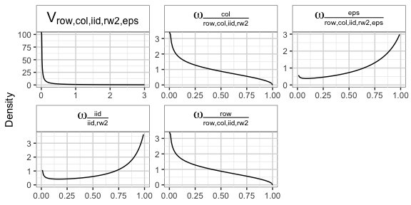

```r
plot_prior(prior1) # or plot(prior)
```

```r
plot_tree_structure(prior1)
```

[interactive chart not shown]

Inference can be carried out by running:

```r
posterior1 <- inference_stan(prior1, iter = 15000, warmup = 5000,
                            seed = 1, init = "0", chains = 1)
plot_posterior_stan(posterior1, param = "prior", prior = TRUE)
```

For inference with INLA we need to include the linear constraint in a different way:

```r
formula_inla <- y ~ lin + mc(row) + mc(col) + mc(iid, constr = TRUE) +
  mc(rw2, model = "rw2", constr = TRUE, extraconstr = list(A = matrix(1:9, 1, 9), e = matrix(0, 1, 1)))
prior1_inla <- make_prior(
  formula_inla, latin_data,
  prior = list(tree = "s1 = (iid, rw2); s2 = (row, col, s1); s3 = (s2, eps)",
               w = list(s1 = list(prior = "pc1", param = 0.75),
                        s2 = list(prior = "dirichlet"),
                        s3 = list(prior = "pc0", param = 0.25))))

posterior1_inla <- inference_inla(prior1_inla)
plot_posterior_stdev(posterior1_inla)
```

### Prior 2

```r
prior2 <- make_prior(
  formula, latin_data,
  prior = list(tree = "s1 = (iid, rw2); s2 = (row, col, s1); (eps)",
               w = list(s1 = list(prior = "pc1", param = 0.75),
                        s2 = list(prior = "dirichlet")),
               V = list(s2 = list(prior = "pc", param = c(sqrt(0.2), 0.05)),
                        eps = list(prior = "pc", param = c(sqrt(0.2), 0.05)))))

prior2
```

```
#> Model: y ~ lin + mc(row) + mc(col) + mc(iid, constr = TRUE) + mc(rw2,
#>     model = "rw2", constr = TRUE, lin_constr = TRUE)
#> Tree structure: iid_rw2 = (iid,rw2); row_col_iid_rw2 = (row,col,iid_rw2); (eps)
#>
#> Weight priors:
#>  w[iid/iid_rw2] ~ PC1(0.75)
#>  (w[row/row_col_iid_rw2], w[col/row_col_iid_rw2]) ~ Dirichlet(3)
#> Total variance priors:
#>  sqrt(V)[row_col_iid_rw2] ~ PC0(0.447213595499958, 0.05)
#> Independent variance priors:
#>  sigma[eps] ~ PC0(0.447213595499958, 0.05)
```

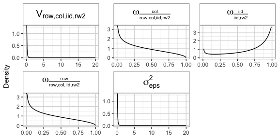

```r
plot_prior(prior2) # or plot(prior2)
```

```r
plot_tree_structure(prior2)
```

[interactive chart not shown]

Inference can be carried out by running:

```r
posterior2 <- inference_stan(prior2, iter = 15000, warmup = 5000,
                            seed = 1, init = "0", chains = 1)
plot_posterior_stan(posterior2)
```

### Prior 3

```r
prior3 <- make_prior(
  formula, latin_data,
  prior = list(tree = "(row); (col); (iid); (rw2); (eps)",
               V = list(
                 row = list(prior = "pc", param = c(sqrt(0.1), 0.05)),
                 col = list(prior = "pc", param = c(sqrt(0.1), 0.05)),
                 iid = list(prior = "pc", param = c(sqrt(0.1), 0.05)),
                 rw2 = list(prior = "pc", param = c(sqrt(0.1), 0.05)),
                 eps = list(prior = "pc", param = c(sqrt(0.1), 0.05))
               )))

prior3
```

```
#> Model: y ~ lin + mc(row) + mc(col) + mc(iid, constr = TRUE) + mc(rw2,
#>     model = "rw2", constr = TRUE, lin_constr = TRUE)
#> Tree structure: (row); (col); (iid); (rw2); (eps)
#>
#> Independent variance priors:
#>  sigma[row] ~ PC0(0.316227766016838, 0.05)
#>  sigma[col] ~ PC0(0.316227766016838, 0.05)
#>  sigma[iid] ~ PC0(0.316227766016838, 0.05)
#>  sigma[rw2] ~ PC0(0.316227766016838, 0.05)
#>  sigma[eps] ~ PC0(0.316227766016838, 0.05)
```

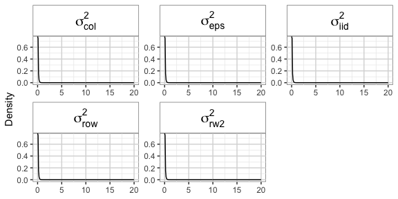

```r
plot_prior(prior3) # or plot(prior3)
```

```r
plot_tree_structure(prior3)
```

[interactive chart not shown]

Inference can be carried out by running:

```r
posterior3 <- inference_stan(prior3, iter = 15000, warmup = 5000,
                            seed = 1, init = "0", chains = 1)
plot_posterior_stan(posterior3)
```

### References

Fuglstad, Geir-Arne, Ingeborg Gullikstad Hem, Alexander Knight, Håvard Rue, and Andrea Riebler. 2020. “Intuitive Joint Priors for Variance Parameters.” *Bayesian Anal.* 15 (4): 1109–37.